# Biostat 203B Homework 2

Due Feb 5 @ 11:59PM

Benson Wu

```r
knitr::opts_chunk$set(echo = TRUE, cache = TRUE)
library(tidyverse)
library(data.table)
library(lubridate)
library(tictoc)
library(scales)
library(stringr)
```

```r
os <- sessionInfo()$running

#Generate path for mimic data
if (str_detect(os, "Linux")) {
  mimic_path <- "/usr/203b-data/mimic-iv"
} else if (str_detect(os, "macOS")) {
  mimic_path <-
    "/Users/bensonwu/Documents/UCLA/2020-2021/Winter 2021/BIOSTAT_203B/mimic-iv"
}

#Generate path for filtered mimic data
if (str_detect(os, "Linux")) {
  mimic_derived_path <- "/usr/203b-data/mimic-iv-derived-data"
} else if (str_detect(os, "macOS")) {
  mimic_derived_path <-
  "/Users/bensonwu/Documents/UCLA/2020-2021/Winter 2021/BIOSTAT_203B/mimic-iv-derived-data"
}
```

Use tidyverse (ggpot2, dplyr) to explore the [MIMIC-IV](https://mimic-iv.mit.edu) data introduced in [homework 1](https://ucla-biostat203b-2021winter.github.io/hw/hw1/hw1.html). (Note, I set this chunk to not evaluate becuase I am knitting this markdown file from my local instead of the teaching server.)

```r
system(str_c("tree -s -L 2 ", shQuote(mimic_path)), intern = TRUE)
```

## Q1. PhysioNet credential

At this moment, you should already get credentialed on the PhysioNet. Please include a screenshot of your `Data Use Agreement for the MIMIC-IV (v0.4)`.

#### Solution

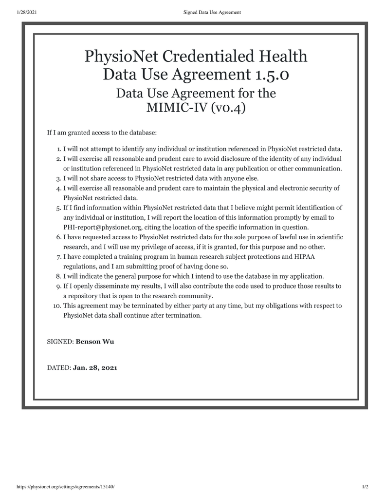

Signed DUA.

## Q2. `read.csv` (base R) vs `read_csv` (tidyverse) vs `fread` (data.table)

There are quite a few utilities in R for reading data files. Let us test the speed of reading a moderate sized compressed csv file, `admissions.csv.gz`, by three programs: `read.csv` in base R, `read_csv` in tidyverse, and `fread` in the popular data.table package. Is there any speed difference?

In this homework, we stick to the tidyverse.

#### Solution

We can use the library `tictoc` to measure code run time.

```r
tic("read.csv")
df1 <- read.csv(str_c(mimic_path,"/core/admissions.csv.gz"))
toc()
```

```
## read.csv: 10.688 sec elapsed
```

```r
tic("read_csv")
df2 <- read_csv(str_c(mimic_path,"/core/admissions.csv.gz"))
toc()
```

```
## read_csv: 5.311 sec elapsed
```

```r
tic("data.table")
df3 <- fread(str_c(mimic_path,"/core/admissions.csv.gz"))
toc()
```

```
## data.table: 2.501 sec elapsed
```

`fread` reads the compressed file the fastest among the three functions. It takes about 2.5 seconds.

We will remove the other data frames and only keep the first for the rest of the assignment.

```r
df_admissions <- df1
remove("df1", "df2", "df3")
```

## Q3. ICU stays

`icustays.csv.gz` (https://mimic-iv.mit.edu/docs/datasets/icu/icustays/) contains data about Intensive Care Units (ICU) stays. Summarize following variables using appropriate numerics or graphs:

- how many unique `stay_id`?
- how many unique `subject_id`?
- length of ICU stay
- first ICU unit
- last ICU unit

#### Solution

Let’s read in the ICU stays data first.

```r
df_icu <- fread(str_c(mimic_path,"/icu/icustays.csv.gz"))
```

**Stay ID**

```r
n_distinct(df_icu$stay_id)
```

```
## [1] 69619
```

There are 69,619 distinct stay ID values.

**Subject ID**

```r
n_distinct(df_icu$subject_id)
```

```
## [1] 50048
```

There are 50,048 distinct subject ID values.

**Length of ICU stay**

```r
summary(df_icu$los)
```

```
##     Min.  1st Qu.   Median     Mean  3rd Qu.     Max.
##   0.0347   1.1339   2.0611   3.9805   4.2022 599.2497
```

After exploring the distribution, it seems like the data is skewed to the right. We can use a log transformation to normalize the length of ICU stays.

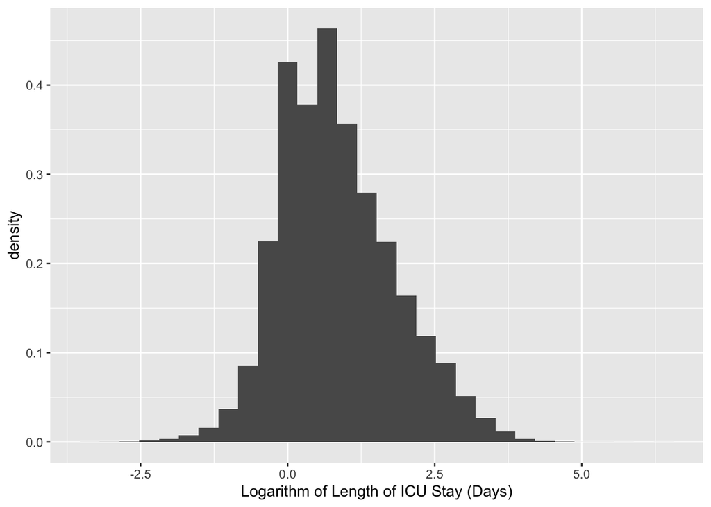

```r
df_icu %>% ggplot(aes(log(los))) + geom_histogram(aes(y=..density..)) +
           xlab("Logarithm of Length of ICU Stay (Days)")
```

**First ICU unit**

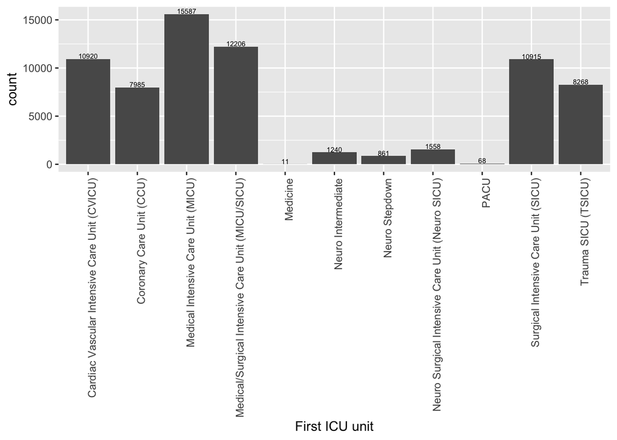

```r
df_icu %>% ggplot(aes(x=factor(first_careunit))) +
        geom_bar() +
        xlab("First ICU unit") +
        theme(axis.text.x=element_text(angle=90,hjust=1)) +
        geom_text(stat='count', aes(label=..count..), size=2, vjust=-0.1)
```

There are 11 distinct First ICU units. The frequency counts are visualized and labeled with the frequqency counts for each unit. The MICU seems to be the most common first ICU unit.

**Last ICU unit**

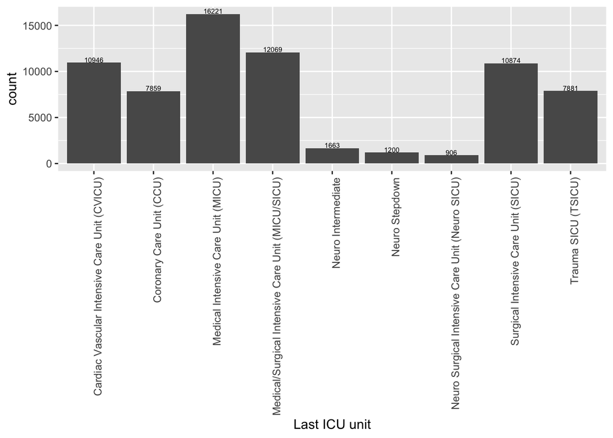

```r
df_icu %>% ggplot(aes(x=factor(last_careunit))) +
        geom_bar() +
        xlab("Last ICU unit") +
        theme(axis.text.x=element_text(angle=90,hjust=1)) +
        geom_text(stat='count', aes(label=..count..), size=2, vjust=-0.1)
```

There are 9 distinct last ICU units. The frequency counts are visualized and labeled with the frequqency counts for each unit. The MICU seems to be the most common last ICU unit.

## Q4. `admission` data

Information of the patients admitted into hospital is available in `ADMISSION.csv.gz`. See https://mimic-iv.mit.edu/docs/datasets/core/admissions/ for details of each field in this file. Summarize following variables using appropriate graphs. Explain any patterns you observe.

- admission year
- admission month
- admission month day
- admission week day
- admission hour (anything unusual?)
- number of deaths in each year
- admission type
- number of admissions per patient
- admission location
- discharge location
- insurance
- language
- martial status
- ethnicity
- death

Note it is possible that one patient (uniquely identified by the `SUBJECT_ID`) is admitted into hospital multiple times. When summarizing some demographic information, it makes sense to summarize based on unique patients.

#### Solution

**Admission year**

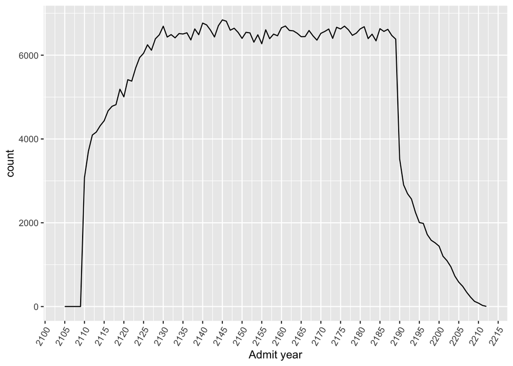

```r
#Parse the year out of the admission time
df_admissions$admit_year <- year(df_admissions$admittime)

df_admissions %>% ggplot(aes(x=admit_year)) +
                  stat_count(geom='line', aes(y=..count..)) +
                  xlab("Admit year") +
                  scale_x_continuous(n.breaks = 20) +
                  theme(axis.text.x=element_text(angle=60,hjust=1))
```

**Admission month**

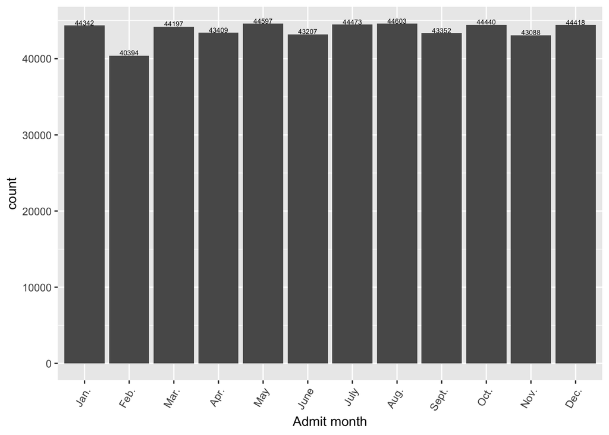

```r
#Parse the month out of the admission time
df_admissions$admit_month <- month(df_admissions$admittime)

months <-c("Jan.", "Feb.", "Mar.","Apr.","May", "June",
           "July", "Aug.", "Sept.", "Oct.", "Nov.", "Dec.")
df_admissions %>% ggplot(aes(x=factor(admit_month))) + geom_bar(stat="count") +
        xlab("Admit month") + scale_x_discrete(labels=months) +
        theme(axis.text.x=element_text(angle=60,hjust=1)) +
        geom_text(stat='count', aes(label=..count..), size=2, vjust=-0.1)
```

The admit month is parsed from the `admittime` variable. The count of each admission month is visualized in a bar graph to see the count of ICU admissions over the different months of the year. The admission months are relatively uniformly distributed.

**Admission month day**

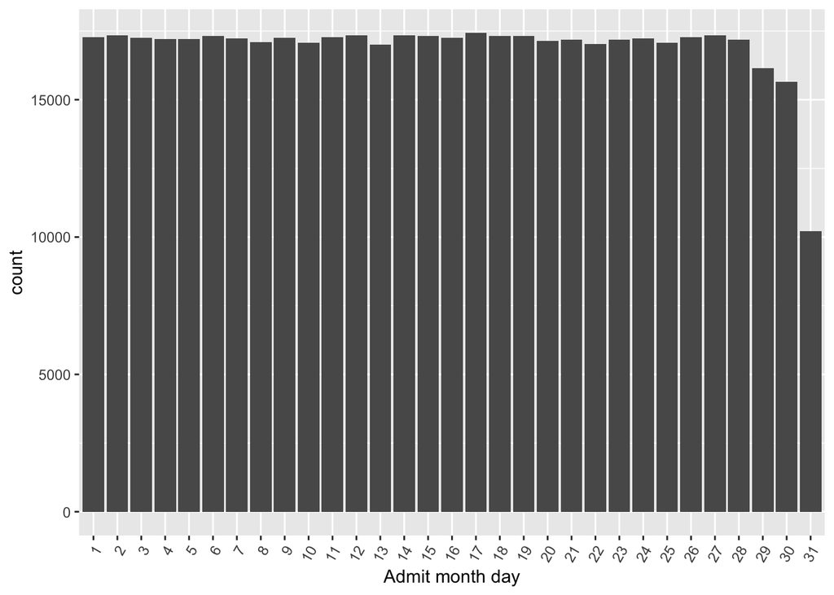

```r
#Parse day of the month from admittime
df_admissions$admit_month_day <- mday(df_admissions$admittime)
df_admissions %>% ggplot(aes(x=factor(admit_month_day))) +
        geom_bar(stat="count") +
        xlab("Admit month day") +
        theme(axis.text.x=element_text(angle=60,hjust=1))
```

The day of the month is parsed from the `admittime` variable. There seem to be a uniform amount of admissions from the 1st to 28th of each month, but there are fewer admissions 29th-31st compared to the other days. There could be especially fewer admissions on the 31st because there are only 7 months with 31 days.

**Admission week day**

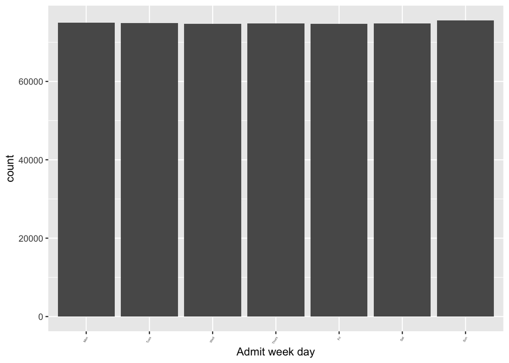

```r
#Parse day of the week from admittime
df_admissions$admit_week_day <- wday(df_admissions$admittime)

#X axis labels
days <-c("Mon", "Tues", "Wed", "Thurs", "Fri", "Sat", "Sun")

df_admissions %>% ggplot(aes(x=factor(admit_week_day))) +
        geom_bar(stat="count") +
        xlab("Admit week day") + scale_x_discrete(labels=days) +
        theme(axis.text.x=element_text(angle=60, size= 3, hjust=1))
```

The day of the week is parsed from the `admittime` variable. The day of the week that individuals are admitted are uniformly distributed.

**Admission hour**

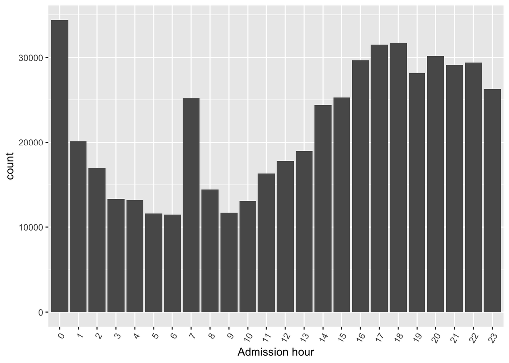

```r
#Parse admission hour from admittime
df_admissions$admit_hour <- hour(df_admissions$admittime)

df_admissions %>% ggplot(aes(x=factor(admit_hour))) + geom_bar(stat="count") +
        xlab("Admission hour") +
        theme(axis.text.x=element_text(angle=60,hjust=1))
```

The admission hour is parsed from the `admittime` variable. Peak admissions seem to happen between midnight and 1 AM. There is also a sudden spike in admissions between the 7AM and 8 AM and then admission steadily rise over the next few hours towards the evening.

**Number of deaths in each year**

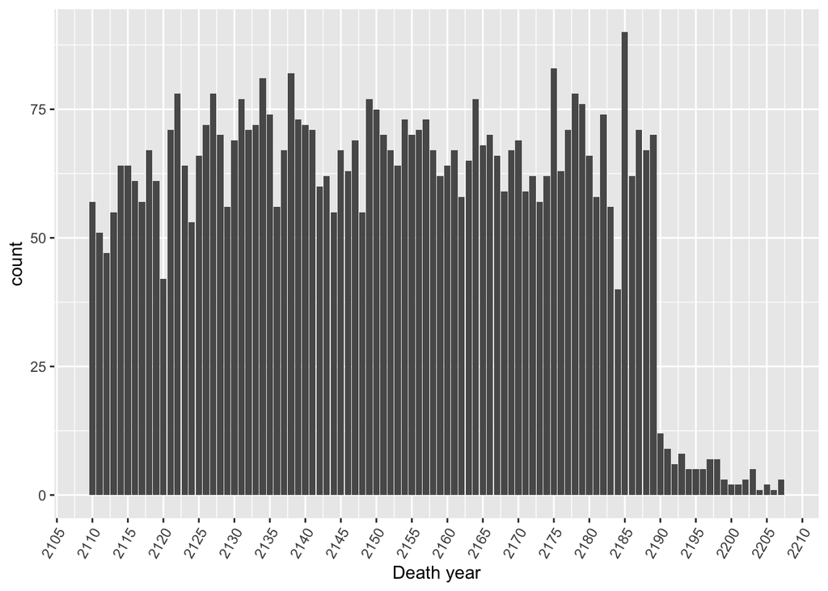

```r
df_admissions$death_year <- year(ymd_hms(df_admissions$deathtime))


df_admissions %>% distinct(., subject_id, .keep_all=TRUE) %>%
                  ggplot(aes(x=death_year)) + geom_bar(stat="count") +
                  xlab("Death year") +
                  theme(axis.text.x=element_text(angle=60,hjust=1)) +
                  scale_x_continuous(n.breaks = 20)
```

Death year was parsed from the `deathtime` variable. To visualize the deaths per year,the data was restricted to unique patients to ensure that a patient’s death was not counted multiple times. Starting from 2190, there seems to be a sharp decrease in the count of deaths per year.

**Admission type**

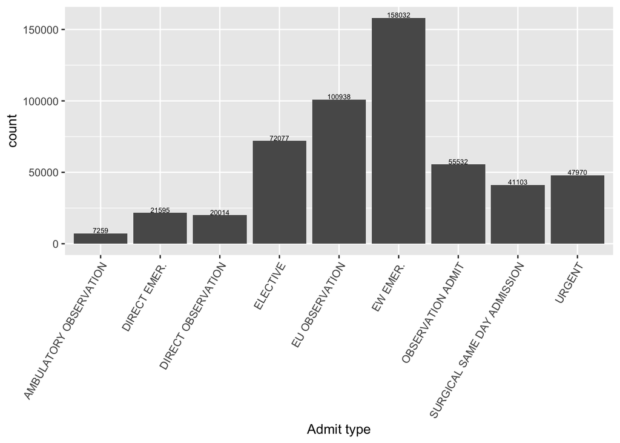

```r
df_admissions %>% ggplot(aes(x=factor(admission_type))) +
        geom_bar(stat="count") +
        xlab("Admit type") +
        theme(axis.text.x=element_text(angle=60,hjust=1)) +
        geom_text(stat='count', aes(label=..count..), size=2, vjust=-0.1)
```

The most common admission type is EW Emergency.

**Number of admissions per patient**

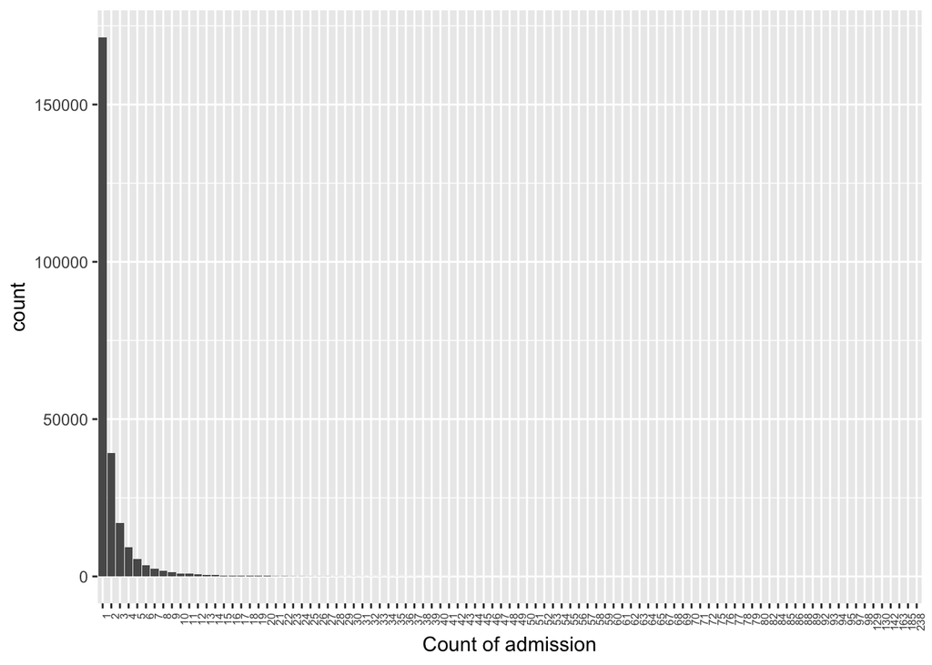

```r
#Create a data frame that contains the count of appeareances for each subject ID
df_admissions_count <- df_admissions %>% count(subject_id)

#Graph counts
df_admissions_count %>% ggplot(aes(x=factor(n))) + geom_bar(stat="count") +
        xlab("Count of admission") +
        theme(axis.text.x=element_text(angle=90,hjust=1,size=6))
```

The documentation for the admission data states that “It is possible for this table to have duplicate `subject_id`, indicating that a single patient had multiple admissions to the hospital.” Therefore, we can count how many times a unique subject ID shows up in the data to get count of admissions. After plotting the count of admission, we can observe that the distribution of the count of admissions is skewed to the right.

**Admission location**

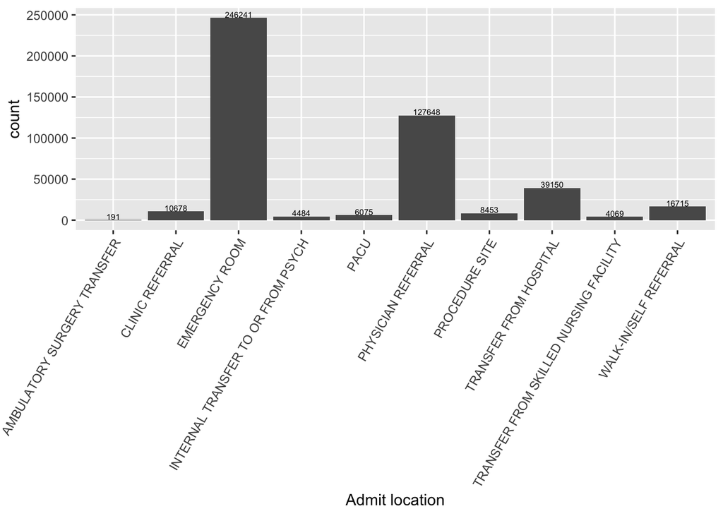

```r
#Recode those with blanks and "information not avaliable" to NA
df_admissions$admission_location[df_admissions$admission_location == ""] <- NA
df_admissions$admission_location[df_admissions$admission_location ==
                                   "INFORMATION NOT AVAILABLE"] <- NA

df_admissions %>% drop_na(admission_location) %>%
        ggplot(aes(x=factor(admission_location))) +
        geom_bar(stat="count") +
        xlab("Admit location") +
        theme(axis.text.x=element_text(angle=60,hjust=1)) +
        geom_text(stat='count', aes(label=..count..), size=2, vjust=-0.1)
```

Those who had blank values or “INFORMATION NOT AVAILABLE” were recoded to missing for this visualization. The most common admission location is the emergency room.

**Discharge location**

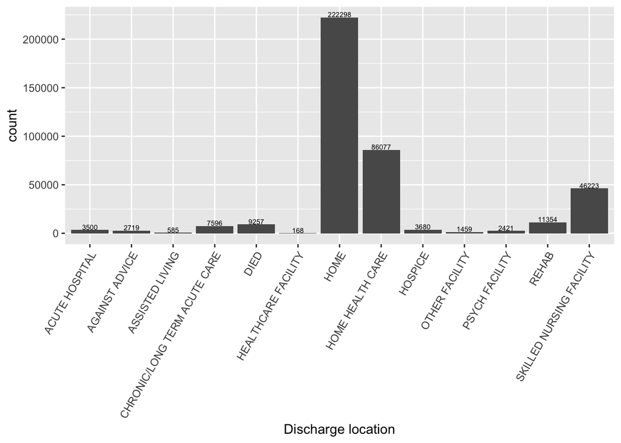

```r
#Recode those with blanks and "information not available" to NA
df_admissions$discharge_location[df_admissions$discharge_location == ""] <- NA

df_admissions %>% drop_na(discharge_location) %>%
        ggplot(aes(x=factor(discharge_location))) +
        geom_bar(stat="count") +
        xlab("Discharge location") +
        theme(axis.text.x=element_text(angle=60,hjust=1)) +
        geom_text(stat='count', aes(label=..count..), size=2, vjust=-0.1)
```

Those who had blank values were recoded to missing. The most common discharge location is at home.

**Insurance**

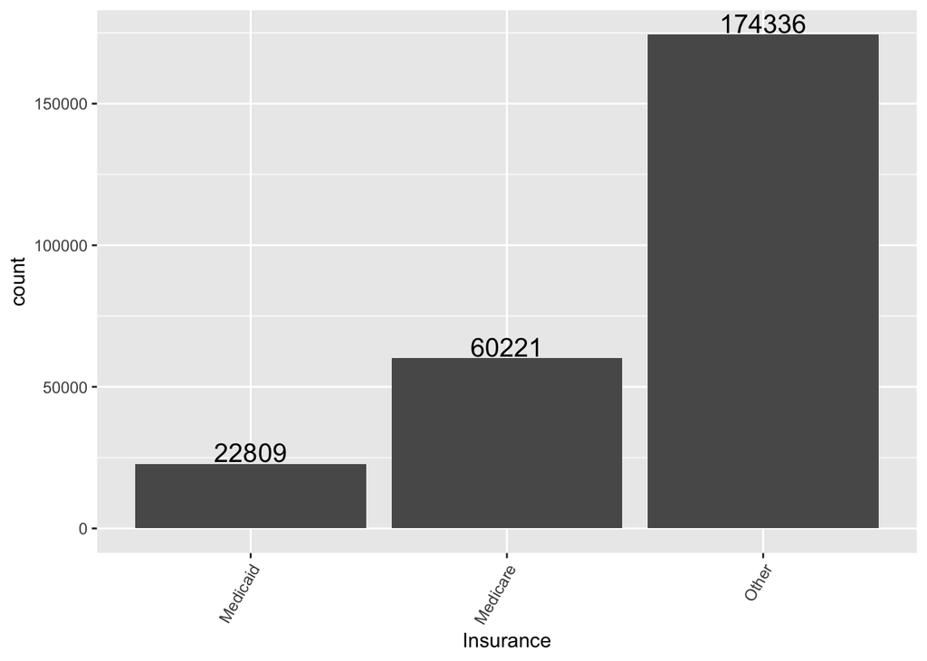

```r
df_admissions %>% distinct(., subject_id, .keep_all=TRUE) %>%
        ggplot(aes(x=factor(insurance))) +
        geom_bar(stat="count") +
        xlab("Insurance") +
        theme(axis.text.x=element_text(angle=60,hjust=1)) +
        geom_text(stat='count', aes(label=..count..), size=5, vjust=-0.1)
```

We examined unique patients for this visualization to avoid counting insurance for subjects who appeared in the data multiple times. Other insurance was the most common type of insurance.

**Language**

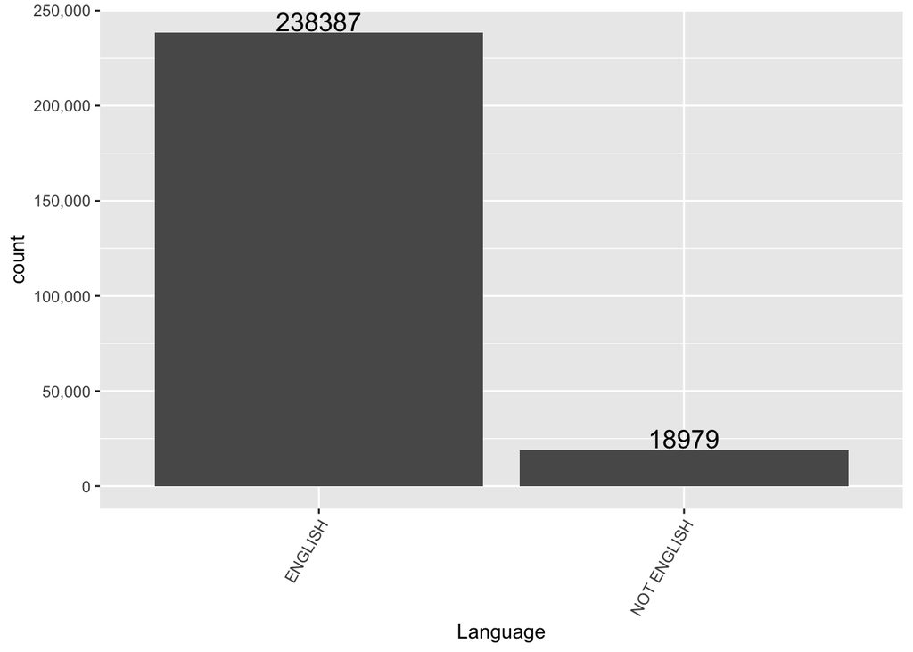

```r
df_admissions$language_new <- recode(df_admissions$language,
                                    "?" = "NOT ENGLISH")

df_admissions %>% distinct(., subject_id, .keep_all=TRUE) %>%
        ggplot(aes(x=factor(language_new))) +
        geom_bar(stat="count") +
        xlab("Language") +
        theme(axis.text.x=element_text(angle=60,hjust=1)) +
        geom_text(stat='count', aes(label=..count..), size=5, vjust=-0.1) +
        scale_y_continuous(labels = comma)
```

Those who had a “?” as a value were recoded to “Not English”, as the other category in this variable is “English.” Additionally, we only examined unique patients for this visualization to avoid counting subjects who appeared multiple times in the data. A majority of the patients spoke English.

**Martial status**

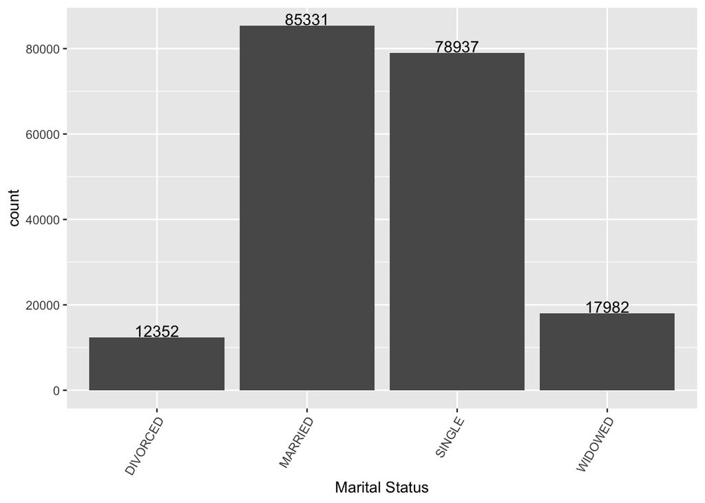

```r
#Turn all blanks into NA
df_admissions$marital_status[df_admissions$marital_status == ""] <- NA

df_admissions %>% drop_na(marital_status) %>%
        distinct(., subject_id, .keep_all=TRUE) %>%
        ggplot(aes(x=factor(marital_status))) +
        geom_bar(stat="count") +
        xlab("Marital Status") +
        theme(axis.text.x=element_text(angle=60,hjust=1)) +
        geom_text(stat='count', aes(label=..count..), size=4, vjust=-0.1)
```

Those who had a blank as a value were recoded to missing. Additionally, we only examined unique patients for this visualization to counting subjects who appeared multiple times in the data. Most of the patients were either married or single.

**Ethnicity**

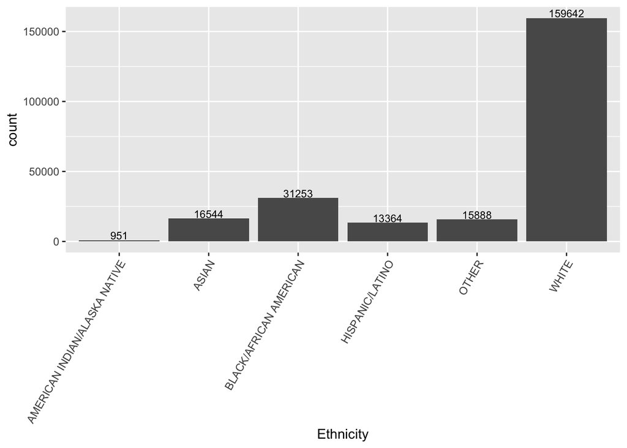

```r
#Recode those who are "UNKNOWN" or "UNABLE TO OBTAIN" as missing
df_admissions$ethnicity[df_admissions$ethnicity == "UNKNOWN"] <- NA
df_admissions$ethnicity[df_admissions$ethnicity == "UNABLE TO OBTAIN"] <- NA

df_admissions %>% distinct(., subject_id, .keep_all=TRUE) %>%
        drop_na(ethnicity) %>%
        ggplot(aes(x=factor(ethnicity))) +
        geom_bar(stat="count") +
        xlab("Ethnicity") +
        theme(axis.text.x=element_text(angle=60,hjust=1)) +
        geom_text(stat='count', aes(label=..count..), size=3, vjust=-0.1)
```

Individuals who ethnicity was unknown or unable to be obtained were ommitted from this visualization. Additionally, we only examined unique patients for this visualization to counting subjects who appeared multiple times in the data. A majority of the patients in this data were White.

**Death**

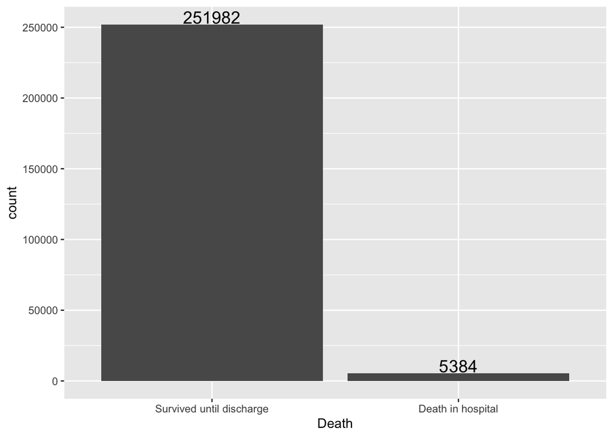

```r
df_admissions %>% distinct(., subject_id, .keep_all=TRUE) %>%
        ggplot(aes(x=factor(hospital_expire_flag))) +
        scale_x_discrete(labels=c("Survived until discharge",
                                  "Death in hospital")) +
        geom_bar(stat="count") +
        xlab("Death") +
        geom_text(stat='count', aes(label=..count..), size=5, vjust=-0.1)
```

We only examined unique patients for this visualization to counting subjects who appeared multiple times in the data. Most patients survived until discharge from the hospital.

## Q5. `patient` data

Explore `patients.csv.gz` (https://mimic-iv.mit.edu/docs/datasets/core/patients/) and summarize following variables using appropriate numerics and graphs:

- `gender`
- `anchor_age` (explain pattern you see)

#### Solution

**Gender**

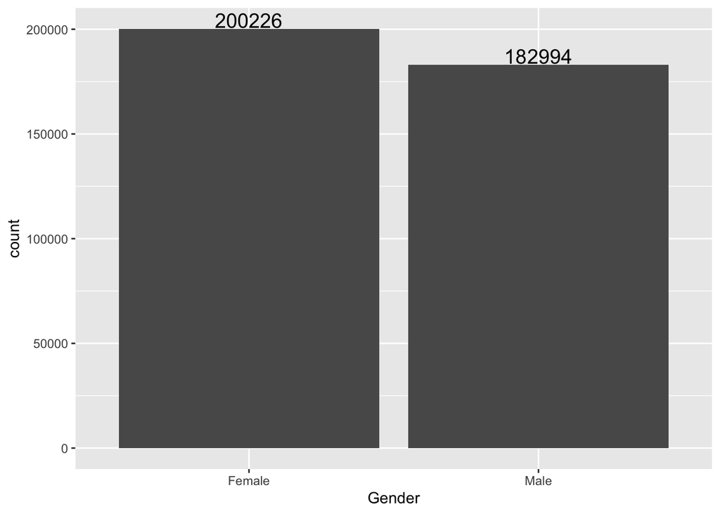

```r
df_patients <- fread(str_c(mimic_path, "/core/patients.csv.gz"))

df_patients %>% distinct(., subject_id, .keep_all=TRUE) %>%
                ggplot(aes(x=factor(gender))) + geom_bar(stat="count") +
                xlab("Gender") + scale_x_discrete(labels=c("Female", "Male")) +
                geom_text(stat='count', aes(label=..count..),
                          size=5, vjust=-0.1)
```

Unique subjects were examined to avoid counting patients multiple times. There are more females than males in this dataset.

**Anchor age**

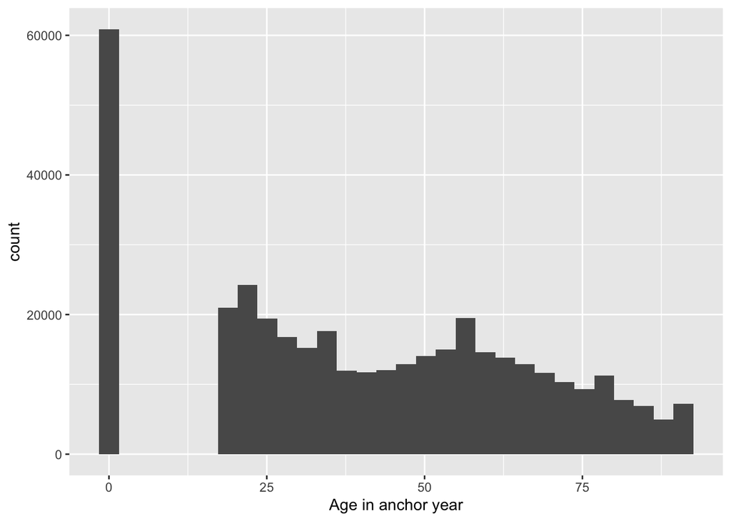

```r
df_patients %>% ggplot(aes(anchor_age)) + geom_histogram() +
        xlab("Age in anchor year")
```

There are a lot of people who report an age of 0 during the anchor year. Perhaps 0 may represent a missing value? Then there are two peaks in the anchor age for individuals in their late teens/early 20’s and for individuals in their 50’s.

## Q6. Lab results

`labevents.csv.gz` (https://mimic-iv.mit.edu/docs/datasets/hosp/labevents/) contains all laboratory measurements for patients.

We are interested in the lab measurements of creatinine (50912), potassium (50971), sodium (50983), chloride (50902), bicarbonate (50882), hematocrit (51221), white blood cell count (51301), glucose (50931), magnesium (50960), calcium (50893), and lactate (50813). Find the `itemid`s of these lab measurements from `d_labitems.csv.gz` and retrieve a subset of `labevents.csv.gz` only containing these items.

#### Solution

First take a look at first lines of the labevents data.

```r
system(str_c("zcat < ",
             shQuote(str_c(mimic_path, "/hosp/labevents.csv.gz")), " | head"),
             intern = TRUE)
```

```
##  [1] "labevent_id,subject_id,hadm_id,specimen_id,itemid,charttime,storetime,value,valuenum,valueuom,ref_range_lower,ref_range_upper,flag,priority,comments"
##  [2] "30331194,12455438,24471620,6107018,51277,2151-05-06 04:45:00,2151-05-06 06:24:00,13.9,13.9,%,10.5,15.5,,STAT,"
##  [3] "30331195,12455438,24471620,6107018,51279,2151-05-06 04:45:00,2151-05-06 06:24:00,3.55,3.55,m/uL,3.9,5.2,abnormal,STAT,"
##  [4] "30331196,12455438,24471620,6107018,51301,2151-05-06 04:45:00,2151-05-06 06:24:00,16.3,16.3,K/uL,4,10,abnormal,STAT,"
##  [5] "30331197,12455438,24471620,6107018,52167,2151-05-06 04:45:00,2151-05-06 06:24:00,46.7,46.7,fL,35.1,46.3,abnormal,STAT,"
##  [6] "30331199,12455438,24471620,70876201,50882,2151-05-06 04:45:00,2151-05-06 07:05:00,23,23,mEq/L,22,32,,STAT,"
##  [7] "30331200,12455438,24471620,70876201,50893,2151-05-06 04:45:00,2151-05-06 07:05:00,8.8,8.8,mg/dL,8.4,10.3,,STAT,"
##  [8] "30331201,12455438,24471620,70876201,50902,2151-05-06 04:45:00,2151-05-06 07:05:00,106,106,mEq/L,96,108,,STAT,"
##  [9] "30331202,12455438,24471620,70876201,50912,2151-05-06 04:45:00,2151-05-06 07:05:00,0.7,0.7,mg/dL,0.4,1.1,,STAT,"
## [10] "30331204,12455438,24471620,70876201,50934,2151-05-06 04:45:00,2151-05-06 07:05:00,3,3,,,,,STAT,"
```

`fread` doesn’t work due to memory issues.

```r
df_labevents <- fread(str_c(mimic_path, "/hosp/labevents.csv.gz"))
```

Let’s try selecting only a few columns and running on local machine. Code is courtesy of Dr. Zhou.

```r
if(!file.exists("labevents_icustays.csv.gz")){
 system.time(df_labevents <-
        fread(str_c(mimic_path, "/hosp/labevents.csv.gz"),
           select = c("subject_id", "hadm_id", "itemid",
                 "charttime", "valuenum"),
           nThread = 4))
 df_labevents %>%
  #Filter for rows that contain matching subject_id and hadm_id in ICU data
  semi_join(df_icu, by = c("subject_id", "hadm_id")) %>%
  #Write this reduced dataframe to a csv file
  fwrite("labevents_icustays.csv.gz", nThread = 4)
}

#Remove the lab events dataframe (if present) to clear memory
remove("df_labevents")
#Read reduced data file
system.time(df_labevents <- fread("labevents_icustays.csv.gz", nThread = 4))
```

```
##    user  system elapsed
##  17.861   6.590  45.946
```

Let’s read in the dictionary for the lab items

```r
df_d_labitems <- fread(str_c(mimic_path,
                             "/hosp/d_labitems.csv.gz"), nThread = 4)
```

This is the quick way to do this question. The lab IDs for the desired lab measurements are given in the question.

```r
#Subset labevents data containing desired item IDs
df_labevents_subset <- subset(df_labevents, itemid %in% c("50912", "50971",
                                  "50983","50902", "50882", "51221", "51301",
                                  "50931", "50960", "50893", "50813")) %>%
  mutate(charttime = ymd_hms(charttime))
```

However, if we weren’t provided with the item IDs we can use this method to search for the item IDs based off of the key words. Code is courtesy of Dr. Zhou.

```r
#Create a vector containing the key words
labitems <- c("creatinine", "potassium", "sodium", "chloride",
              "bicarbonate", "hematocrit", "white blood cell",
              "glucose", "magnesium", "calcium", "lactate")

#Create an empty vector that is the length of labitems
itemids <- rep(0, length(labitems))
i<-1

#Loop through each lab item
for(labitem in labitems){
  print(str_interp("search for ${labitem}"))

  #Search for the item IDs that contain these keywords and store in list
  itemid_list <- df_d_labitems %>%
    filter(str_detect(label, regex(labitem, ignore_case = T))) %>%
    .$itemid

  #In each item list, retreive the one with the most occurences in labevents
  itemid <-  df_labevents %>%
    filter(itemid %in% itemid_list) %>%
    count(itemid) %>%
    arrange(desc(n)) %>%
    slice(1) %>%
      .$itemid
    itemids[i] <- itemid
    i <- i+1
}
```

```
## [1] "search for creatinine"
## [1] "search for potassium"
## [1] "search for sodium"
## [1] "search for chloride"
## [1] "search for bicarbonate"
## [1] "search for hematocrit"
## [1] "search for white blood cell"
## [1] "search for glucose"
## [1] "search for magnesium"
## [1] "search for calcium"
## [1] "search for lactate"
```

Create a tibble that contains the item IDs and item names

```r
labitem_itemid <- tibble(itemid = itemids, labitem = labitems) %>%
  print(width=Inf)
```

```
## # A tibble: 11 x 2
##    itemid labitem
##     <dbl> <chr>
##  1  50912 creatinine
##  2  50971 potassium
##  3  50983 sodium
##  4  50902 chloride
##  5  50882 bicarbonate
##  6  51221 hematocrit
##  7  51301 white blood cell
##  8  50931 glucose
##  9  50960 magnesium
## 10  50893 calcium
## 11  50813 lactate
```

[output not shown]

## Q7. Vitals from chartered events

We are interested in the vitals for ICU patients: heart rate, mean and systolic blood pressure (invasive and noninvasive measurements combined), body temperature, SpO2, and respiratory rate. Find the `itemid`s of these vitals from `d_items.csv.gz` and retrieve a subset of `chartevents.csv.gz` only containing these items.

`chartevents.csv.gz` (https://mimic-iv.mit.edu/docs/datasets/icu/chartevents/) contains all the charted data available for a patient. During their ICU stay, the primary repository of a patient’s information is their electronic chart. The `itemid` variable indicates a single measurement type in the database. The `value` variable is the value measured for `itemid`.

`d_items.csv.gz` (https://mimic-iv.mit.edu/docs/datasets/icu/d_items/) is the dictionary for the `itemid` in `chartevents.csv.gz`.

#### Solution

Let’s read in the dictionary for the item IDs in `chartevents.csv.gz`

```r
df_d_items<-fread(str_c(mimic_path, "/icu/d_items.csv.gz"), nThread = 4)
```

Let’s find the item IDs of the following variables: heart rate, mean and systolic blood pressure (invasive and noninvasive measurements combined), body temperature, SpO2, and respiratory rate.

```r
df_d_items %>%
  filter(str_detect(str_to_lower(label), "heart rate"))
#220045 - Heart Rate
df_d_items %>%
  filter(str_detect(str_to_lower(label), "blood pressure"))
#220052 - Arterial blood pressure mean
#220050 - Arterial blood pressure systolic
#220181 - Non Invasive Blood Pressure mean
#220179 - Non Invasive Blood Pressure systolic

df_d_items %>%
  filter(str_detect(str_to_lower(label), "temperature"))
#223761 - Temperature Fahrenheit

df_d_items %>%
  filter(str_detect(str_to_lower(label), "O2 saturation"))
#220277 -   O2 saturation pulseoxymetry

df_d_items %>%
  filter(str_detect(str_to_lower(label), "respiratory rate"))
#220210 -   Respiratory Rate
```

Or we can also do it the way that it was done in lecture to streamline the search process more. Code is courtesy of Dr. Zhou.

```r
chartitems <- c("heart rate", "Blood pressure mean", "systolic",
                "temperature", "O2 saturation", "respiratory rate")

for(chartitem in chartitems){
  print(str_interp("search for ${chartitem}"))
  df_d_items %>% filter(str_detect(label, regex(chartitem, ignore_case = T)))
}
```

```
## [1] "search for heart rate"
## [1] "search for Blood pressure mean"
## [1] "search for systolic"
## [1] "search for temperature"
## [1] "search for O2 saturation"
## [1] "search for respiratory rate"
```

*Item IDs* - For heart rate, we will use item ID 220045 with the label “Heart Rate” - For mean blood pressure, we will use item ID 220052 with the label “Arterial blood pressure mean”. Arterial blood pressure is synonymous for blood pressure. - For systolic blood pressure, we will use item ID 220050 with the label Arterial blood pressure systolic - For non-invasive mean blood pressure, we will use item ID 220181 with the label “Non Invasive Blood Pressure mean” - For non-invasive systolic blood pressure, we will use item ID 220179 with the label “Non Invasive Blood Pressure systolic” - For temperature, we will use item ID 223761 with the label “Temperature Fahrenheit”. We could have chosen the celsius version, but we will use the fahrenheit version for this assignment. - For SpO2, we will use item ID 220277 with the label “O2 saturation pulseoxymetry”. A Pulse oximetry measure oxygen saturation levels, so this variable is appropriate for SpO2. - For respiratory rate, we will use item ID 220210 with the label Respiratory Rate

Let’s try to read in the `chartevents_short.csv.gz` data now.

Trial 1: Cannot read this in R even on my local machine.

```r
if(!file.exists("chartevents_short.csv.gz")){
 system.time(df_chartevents <-
        fread(str_c(mimic_path, "/icu/chartevents.csv.gz"),
           select = c("subject_id", "hadm_id", "itemid",
                 "charttime", "valuenum"),
           nThread = 4))
 # df_chartevents %>%
 #  semi_join(df_icu, by = c("subject_id", "hadm_id")) %>%
 #  fwrite("chartevents_short.csv.gz", nThread = 4)
}
# system.time(df_labevents <- fread("chartevents_short.csv.gz", nThread = 4))
# df_labevents %>%
#  as.tibble() %>%
#  print(width = Inf)
```

Trial 2:We will use Dr. Zhou’s bash script to create a filtered `chartevents_filtered_itemid.csv.gz`. I ran this script on my local to generate the data.

```bash
zcat < chartevents.csv.gz | awk -F, '{OFS = ","} {if ($6 == 220045 || \
$6 == 220052 || $6 == 220050 || $6 == 220181 || $6 == 220179 || \
$6 == 223761 || $6 == 220277 || $6 == 220210) print $1, $2, $3, $4, $6, $8}' | \
gzip > chartevents_filtered_itemid.csv.gz
```

Read in filtered data set that contains the subset of `chartevents_short.csv.gz` with the desired items.

```r
df_chartevents <- fread(str_c(mimic_derived_path,
                              "/chartevents_filtered_itemid.csv.gz"),
                        header=FALSE,
                        col.names = c("subject_id",
                                      "hadm_id",
                                      "stay_id",
                                      "charttime",
                                      "itemid",
                                      "valuenum"),
                        nThread=4)

as_tibble(df_chartevents) %>%
  mutate_at(c("subject_id", "hadm_id", "stay_id", "itemid"), as.numeric) %>%
  mutate(charttime=ymd_hms(charttime))
```

```
## # A tibble: 37,527,076 x 6
##    subject_id  hadm_id  stay_id charttime           itemid valuenum
##         <dbl>    <dbl>    <dbl> <dttm>               <dbl>    <dbl>
##  1   10003700 28623837 35053963 2165-04-24 05:28:00 220179    152
##  2   10003700 28623837 35053963 2165-04-24 05:28:00 220181    110
##  3   10003700 28623837 35053963 2165-04-24 05:30:00 220045     65
##  4   10003700 28623837 35053963 2165-04-24 05:30:00 220210     14
##  5   10003700 28623837 35053963 2165-04-24 05:31:00 220277    100
##  6   10003700 28623837 35053963 2165-04-24 05:38:00 223761     97.6
##  7   10003700 28623837 35053963 2165-04-24 06:00:00 220045     56
##  8   10003700 28623837 35053963 2165-04-24 06:00:00 220179    126
##  9   10003700 28623837 35053963 2165-04-24 06:00:00 220181     88
## 10   10003700 28623837 35053963 2165-04-24 06:00:00 220210     14
## # … with 37,527,066 more rows
```

Create a tibble that contains the item IDs and item names

```r
chartevents_itemid <- tibble(itemid = c(220045, 220052, 220050, 220181,
                                        220179, 223761, 220277, 220210),
                            labitem = c("heart_rate", "arterial_BP_mean",
                            "arterial_BP_sys", "noninvasive_bp",
                            "noninvasive_bp_sys", "temperature_far", "SpO2",
                            "respiratory_rate")) %>%
  print(width=Inf)
```

```
## # A tibble: 8 x 2
##   itemid labitem
##    <dbl> <chr>
## 1 220045 heart_rate
## 2 220052 arterial_BP_mean
## 3 220050 arterial_BP_sys
## 4 220181 noninvasive_bp
## 5 220179 noninvasive_bp_sys
## 6 223761 temperature_far
## 7 220277 SpO2
## 8 220210 respiratory_rate
```

## Q8. Putting things together

Let us create a tibble for all ICU stays, where rows are

- first ICU stay of each unique patient
- adults (age at admission > 18)

and columns contains at least following variables

- all variables in `icustays.csv.gz`
- all variables in `admission.csv.gz`
- first lab measurements during ICU stay
- first vitals measurement during ICU stay
- an indicator variable whether the patient died within 30 days of hospital admission

#### Solution

First, let’s create a dataframe that contains the first ICU stay of each unique patient and patients who are age >18 at admission.

```r
df_icu_uniq <- df_icu %>%
  #Keep unique patients
  group_by(subject_id)  %>%
  #First ICU stay only
  filter(rank(intime)==1) %>%
  #Ungroup the tibble
  ungroup() %>%
  #keep all the rows in the ICU stay tibble and
  #then for each row match df_admission by subject_id and hadm_id
  left_join(df_admissions, by=c("subject_id", "hadm_id")) %>%
  left_join(df_patients, by = "subject_id") %>%
  #only keep adults whose age at admission is >18
  mutate(age_at_adm = year(admittime) - anchor_year + anchor_age) %>%
  filter(age_at_adm > 18)
```

Now we want to merge this with the lab events data.

```r
df_icu_uniq <- df_labevents_subset %>%
  #only keep subject id + hadm id that are in df_icu_uniq
  semi_join(df_icu_uniq, by = c("subject_id", "hadm_id"))  %>%
  # #pull in the intime of that ICU stay
  left_join(select(df_icu_uniq, subject_id, hadm_id, intime),
            by = c("subject_id", "hadm_id")) %>%
  mutate(intime=ymd_hms(intime)) %>%
  #only keep lab items after ICU intime
  filter(charttime >= intime) %>%
  #group by item id
  group_by(subject_id, itemid) %>%
  #only keep the first charttime for each item
     #Sort according to charttime within each group and
     #take the top 1 in each sorted group
  arrange(charttime, .by_group=TRUE) %>% slice_head(n=1) %>%
  #We don't need charttime and intime anymore
  select(-charttime, -intime) %>%
  #Turn itemid into columns and assign the values to the variables
  spread(key = itemid, value = valuenum) %>%
  #Merge with df_icu_uniq
  right_join(df_icu_uniq, by = c("subject_id", "hadm_id")) %>%
  ungroup() %>%
  # #More informative column names from Question 6
  rename_at(vars(as.character(labitem_itemid$itemid)),
                 ~labitem_itemid$labitem)
```

Now let’s merge the data with chartevents to get the first vital measurments during ICU stay

Let’s clear some memory in the environment first before running the next chunk.

```r
rm("df_admissions", "df_admissions_count",
   "df_labevents", "df_labevents_subset")
```

```r
df_icu_uniq_final <-
  df_chartevents %>%
  #only keep subject id + hadm id that are in df_icu_uniq
  semi_join(df_icu_uniq, by = c("subject_id", "hadm_id"))  %>%
  left_join(select(df_icu_uniq, subject_id, hadm_id, intime)
            , by = c("subject_id", "hadm_id")) %>%
  #only keep lab items after ICU intime
  filter(charttime >= intime) %>%
  #group by item id
  group_by(subject_id, itemid) %>%
  #only keep the first charttime for each item
     #Sort according to charttime within each group
     #and take the top 1 in each sorted group
  arrange(charttime, .by_group=TRUE) %>% slice_head(n=1) %>%
  #We don't need charttime and intime anymore
  select(-charttime, -intime) %>%
  #Turn itemid into columns and assign the values to the variables
  spread(key = itemid, value = valuenum) %>%
  right_join(select(df_icu_uniq,-one_of("stay_id")),
  by = c("subject_id", "hadm_id")) %>%
  ungroup() %>%
  # #More informative column names from Question 6
  rename_at(vars(as.character(chartevents_itemid$itemid)),
                 ~chartevents_itemid$labitem) %>%
  #create a var that represents if a patient died within 30 days of admission
  mutate(days_before_death = as.numeric((ymd_hms(deathtime)-ymd_hms(admittime)),
         units="days")) %>%
  mutate(died_within_30_days = ifelse(days_before_death<=30, 1, 0)) %>%
  print(width=Inf)
```

```
## # A tibble: 50,688 x 55
##    subject_id  hadm_id  stay_id heart_rate arterial_BP_sys arterial_BP_mean
##         <int>    <int>    <int>      <dbl>           <dbl>            <dbl>
##  1   10000032 29079034 37529680         91              NA               NA
##  2   10000980 26913865 36742749         77              NA               NA
##  3   10001217 24597018 30327812         86              NA               NA
##  4   10001725 25563031 37542711         55              NA               NA
##  5   10001884 26184834 31832304         38              NA               NA
##  6   10002013 23581541 37106138         80             134               94
##  7   10002155 23822395 34599502         68             115               82
##  8   10002223 22494570 39908879        100              NA               NA
##  9   10002428 28662225 31956612        124              NA               NA
## 10   10002428 28662225 39157783         NA             102               69
##    noninvasive_bp_sys noninvasive_bp respiratory_rate  SpO2 temperature_far
##                 <dbl>          <dbl>            <dbl> <dbl>           <dbl>
```

[output cut: 143 more lines]